# Sesión 2: Resumen

Introducción a R. Ciencias Políticas

Javier Kniffki

[figure not shown]

## RMarkdown

Los ejercicios prácticos se presentarán en distintos formatos utilizando RMarkdown. Probablemente una de los mejores manuales por el momento es el de Yihui Xie, J. J. Allaire y Garrett Grolemund que puede consultarse en:

https://bookdown.org/yihui/rmarkdown/

También existe otro manual realizado por los profesores Fernández-Casal, R. y Cotos-Yáñez, T.R. de la Universidade da Coruña. Puede consultarse en:

https://rubenfcasal.github.io/bookdown_intro/

## Funciones propias

*Tip: Guarda tus funciones en scripts aparte, coméntalas correctamente y reutilízalas cuando las necesites cargándolas a la sesión con `load("mifuncion.R")`*

La estructura general es:

```r
mifuncion <- function(arumento1, argumento2, ...) {
        expresiones
        return(objeto)
}
```

Es importante por motivos de estilo y para leer el código con mayor facilidad mantener esta estructura. Toda función en R cuenta con tres partes elementales:

- Nombre de la función.
- Cuerpo (el código entre corchetes).
- Argumentos.

Observemos que cada línea del código entre corchetes (el cuerpo) suele ser una sentencia u operación. Aunque R ignora los espacios, separarlo en líneas hace más fácil la lectura y R ejecuta la expresión entera entre corchetes.

**Cuerpo**

Veamos un ejemplo.

- `sample()` Toma una muestra de n elementos de x con o sin remplazamiento.

```r
#función anónima
tirar.dado <- function() {
        dado <- 1:6
        dado.s <- sample(dado, 2)
        sum(dado.s)
}
```

Vemos que nos devuelve como resultado la última operación del cuerpo de la función. Si mandamos llamar nuestra función sin los paréntesis nos devuelve el cuerpo de la función:

```r
tirar.dado
```

```
## function() {
##         dado <- 1:6
##         dado.s <- sample(dado, 2)
##         sum(dado.s)
## }
```

```r
body(tirar.dado) #equivalente
```

```
## {
##     dado <- 1:6
##     dado.s <- sample(dado, 2)
##     sum(dado.s)
## }
```

**Argumentos**

*Tip: Podemos consultar los argumentos de una función propia o de una librería con `?lafuncion()` No intentes aprenderte todos los argumentos de una función.*

La anterior función es “anónima”; opera sin necesidad de pasarle ningún argumento. Lo interesante es que podemos pasarle cualquier vector, operación, objeto, ¡otra función!… a nuestra función y pedirle que opere con él.

- `length()` Nos devuelve la longitud del vector.
- `sum()` Suma los elementos del vector numérico.
- `return()` Nos devuelve el valor de la expresión evaluada.

```r
mimedia <- function(x) {
        media <- sum(x) / length(x)
        return(media)
}
mimedia()
```

```
## Error in mimedia(): el argumento "x" está ausente, sin valor por omisión
```

Nos devuelve un error porque la función `mimedia` necesita al objeto `x`, que no hemos definido, para realizar su función. Al objeto `x` podemos definirlo (i) dentro del cuerpo de la función, (ii) asignándole valores por defecto al argumento o, (iii) fuera de la función.

*(i)*

```r
mimedia <- function(x) {
        x <- 1:6
        media <- sum(x) / length(x)
        return(media)
}
mimedia()
```

```
## [1] 3.5
```

*(ii)*

```r
mimedia <- function(x = 1:6) {
        media <- sum(x) / length(x)
        return(media)
}
mimedia()
```

```
## [1] 3.5
```

*(iii)*

```r
a <- 1:6
mimedia <- function(x) {
        media <- sum(x) / length(x)
        return(media)
}
mimedia(x = a)
```

```
## [1] 3.5
```

Tip: Para el cuerpo de las funciones creadas por nosotros es mejor acceder a los elementos de la manera básica que con el universo `tidyverse` u otras librerías.

## Lectura y escritura de datos

**Directorio de trabajo**

Cada vez que abrimos R la sesión se vincula a un directorio por defecto *(working directory)*. Es ahí donde R busca los datos cuando intentamos cargarlos y es ahí donde los guarda. Para saber que directorio se está utilizando:

```r
getwd()
```

```
## [1] "C:/Users/Kifirifis/Desktop/KStats/CURSOS/CURSO R/Ecología 2019"
```

Si queremos cambiarlo tendremos que especificar la ruta completa con la función `setwd()`. Ésta podemos copiarla y pegarla de las ventanas de navegación e, importante, tenemos que sustituir el *backslash* `\` por `/` y entrecomillar el texto.

```r
setwd("una_carpeta/miproyecto")
```

Lo más recomendable, a efectos de compartir código es abrir un nuevo “proyecto” en el entorno de RStudio. De esta manera no tendremos que cambiar en cada sesión nuestro directorio de trabajo y, sobre todo, no tendremos que enviar código basura a nuestros colaboradores.

**Textos planos**

Es una de las maneras más comunes de almacenar datos (el .csv, .txt … son textos planos) porque son muy simples y pueden ser leídos por muchos programas incluso por editores de texto básicos como un bloc de notas. Si te das cuenta, los datos públicos abiertos suelen venir en este formato. La función más común para leer texto plano es `read.table` que admite los siguientes argumentos entre otros (recuerda que puedes ver los argumentos que acepta cualquier función consultando la ayuda de r `?unafuncion()`):

- sep
- header
- na.strings

*Cargamos el archivo `calidadaire.txt` al entorno de trabajo*

```r
datos <- read.table("DATA/calidadaire.txt", header = T)
```

A su vez podemos guardar el objeto, supongamos que en formato .csv utilizando la función `write.csv`. Observa que es muy intuitivo y sigue la misma lógica para otras extensiones.

**Otros tipos de archivos**

Si bien es lo más común trabajar con texto plano, hemos de saber que en R podemos leer prácticamente cualquier tipo de archivos, desde html’s, acceder a API’s, sql, mysql, wikipedia, .px, .tiff, .sav, .dbf, .xlxs … Aunque para ello tendremos que instalar paquetes desde el repositorio CRAN o desde cualquier otro. (Ver cargar paquetes) Una de las librerías más utilizadas (utilizamos indistintamente librerías y paquetes en este contexto) para cargar datos procedentes de SW específico es `foreign` que instalaremos en nuestro equipo y cargaremos como hemos aprendido antes.

```r
library(foreign)
```

- `ls()` Nos devuelve los objetos de un entorno específico.

*Tip: Con la siguiente sentencia podemos ver el listado de todas las funciones de una librería: ls(“package:foreign”)*

```r
ls("package:foreign")
```

```
##  [1] "data.restore"  "lookup.xport"  "read.arff"     "read.dbf"
##  [5] "read.dta"      "read.epiinfo"  "read.mtp"      "read.octave"
##  [9] "read.S"        "read.spss"     "read.ssd"      "read.systat"
## [13] "read.xport"    "write.arff"    "write.dbf"     "write.dta"
## [17] "write.foreign"
```

Supongamos que queremos leer un archivo .sav

```r
datos <- read.spss("DATA/control.sav", to.data.frame = T) #es recomendable convertir los archivos .sav a objetos tipo data.frame utilizando el argumento to.data.frame = T
```

```
## re-encoding from UTF-8
```

Para una consulta rápida podemos consultar la “chuleta” (*Cheatsheet*) “data_import”.

## Exploración inicial de un data.frame

Una vez hemos abierto un proyecto nuevo o abierto uno ya existente, hemos cargado nuestros datos en la sesión y hemos llamado a nuestras librerías si es el caso, solemos realizar una serie de operaciones para darnos una idea de los datos con los que estamos trabajando.

Asignemos al objeto `datos` el data set `iris`

```r
datos <- iris
```

- `View(datos)` Invocamos una hoja donde podemos explorar los datos. No es recomendable si tenemos una base muy pesada.

```r
View(datos)
```

Vemos los nombres de las variables:

```r
names(datos)
```

```
## [1] "Sepal.Length" "Sepal.Width"  "Petal.Length" "Petal.Width"  "Species"
```

`names()` Nos devuelve un vector caracter con el atributo “nombre” de cada variable en `datos`.

Vemos la cabecera y la cola de los datos:

```r
head(datos)
```

```
##   Sepal.Length Sepal.Width Petal.Length Petal.Width Species
## 1          5.1         3.5          1.4         0.2  setosa
## 2          4.9         3.0          1.4         0.2  setosa
## 3          4.7         3.2          1.3         0.2  setosa
## 4          4.6         3.1          1.5         0.2  setosa
## 5          5.0         3.6          1.4         0.2  setosa
## 6          5.4         3.9          1.7         0.4  setosa
```

```r
tail(datos)
```

```
##     Sepal.Length Sepal.Width Petal.Length Petal.Width   Species
## 145          6.7         3.3          5.7         2.5 virginica
## 146          6.7         3.0          5.2         2.3 virginica
## 147          6.3         2.5          5.0         1.9 virginica
## 148          6.5         3.0          5.2         2.0 virginica
## 149          6.2         3.4          5.4         2.3 virginica
## 150          5.9         3.0          5.1         1.8 virginica
```

- `str()` Nos informa sobre la estructura interna de nuestro data frame.

```r
str(datos)
```

```
## 'data.frame':    150 obs. of  5 variables:
##  $ Sepal.Length: num  5.1 4.9 4.7 4.6 5 5.4 4.6 5 4.4 4.9 ...
##  $ Sepal.Width : num  3.5 3 3.2 3.1 3.6 3.9 3.4 3.4 2.9 3.1 ...
##  $ Petal.Length: num  1.4 1.4 1.3 1.5 1.4 1.7 1.4 1.5 1.4 1.5 ...
##  $ Petal.Width : num  0.2 0.2 0.2 0.2 0.2 0.4 0.3 0.2 0.2 0.1 ...
##  $ Species     : Factor w/ 3 levels "setosa","versicolor",..: 1 1 1 1 1 1 1 1 1 1 ...
```

Vemos que nos da la información del objeto `datos`. Nos dice que es un “data.frame” de dimensiones 150 x 5 (las dimension podemos obtenerla con `dim()`) y de cada variable nos indica que tipo de objeto es. Si nuestra variable es factor nos indica el número de niveles y además nos muestra los primeros valores de cada variable.

- `missmap()` Vistazo gráfico de nuestros valores perdidos. Es necesario cargar la librería `library(Amelia)`. No recomendable para bases muy grandes.

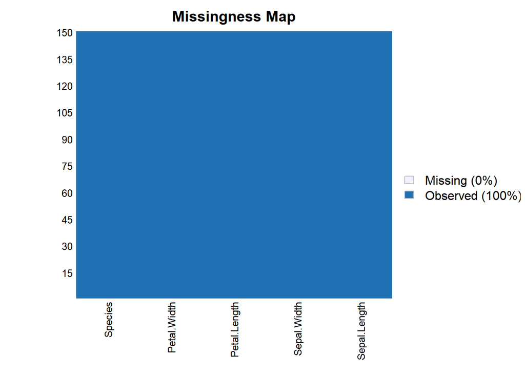

```r
library(Amelia)
missmap(datos)
```

- `summary()` Es una función genérica. Ver detalles con `?summary()`

En nuestro ejemplo `summary()` nos devuelve los estadísticos principales:

```r
summary(datos)
```

```
##   Sepal.Length    Sepal.Width     Petal.Length    Petal.Width
##  Min.   :4.300   Min.   :2.000   Min.   :1.000   Min.   :0.100
##  1st Qu.:5.100   1st Qu.:2.800   1st Qu.:1.600   1st Qu.:0.300
##  Median :5.800   Median :3.000   Median :4.350   Median :1.300
##  Mean   :5.843   Mean   :3.057   Mean   :3.758   Mean   :1.199
##  3rd Qu.:6.400   3rd Qu.:3.300   3rd Qu.:5.100   3rd Qu.:1.800
##  Max.   :7.900   Max.   :4.400   Max.   :6.900   Max.   :2.500
##        Species
##  setosa    :50
##  versicolor:50
##  virginica :50
##
##
##
```

R nos devuelve de cada variable continua el mínimo, el máximo, el primer y tercer cuartil además de la media y la mediana. De la variable factor hace un conteo de las observaciones por nivel. En nuestro ejemplo no tenemos valores perdidos, si los hubiere, también vendrían especificados para cada variable.

- `var()` Nos da la cuasivarianza de un vector numérico.

La función `summary()` no nos da la cuasivarianza por defecto. Para calcularla utilizamos:

```r
var(datos$Sepal.Length)
```

```
## [1] 0.6856935
```

```r
round(var(datos$Sepal.Length), 3)
```

```
## [1] 0.686
```

Si queremos saber la cuasivarianza de todas las variables numéricas de nuestro data frame ¿Iremos calculando una por una? Lo mejor es pasarle un ciclo. Hemos especificado anteriormente el “ciclo for”, sin embargo, hemos de saber que en R los *loops* “naturales” son los pertenecientes a la familia `apply` que iremos introduciendo durante el curso.

- `lapply(x = vector, función)` Aplica a cada elemento una función y nos devuelve un objeto tipo `list()`.

A cada una de las variables numéricas les pasamos la función `var()`. Observa que no es necesario en este caso poner los paréntesis despues de `var`.

```r
lapply(datos[,1:4], var)
```

```
## $Sepal.Length
## [1] 0.6856935
##
## $Sepal.Width
## [1] 0.1899794
##
## $Petal.Length
## [1] 3.116278
##
## $Petal.Width
## [1] 0.5810063
```

Si no nos gusta esta presentación podemos convertir la lista que nos ha devuelto R en un data.frame coercionando el objeto y además redondeando a 3 decimales. (Ver coercionar).

```r
round(as.data.frame(lapply(datos[,1:4], var)), 3)
```

```
##   Sepal.Length Sepal.Width Petal.Length Petal.Width
## 1        0.686        0.19        3.116       0.581
```

## Operaciones con variables Tidyverse

En este epígrafe veremos dos enfoques muy comunes en el tratamiento de datos en R. El primero es el enfoque `tidyverse` y el segundo con R base. Empezaremos mostrando el primero.

Cargaremos la librería `dplyr`.

```r
library(dplyr)
```

Podemos ver que el número de funciones que contiene esta librería es muy grande, y es que es una de las más utilizandas para el manejo de datos.l

```r
length(ls("package:dplyr"))
```

```
## [1] 288
```

- `select()` Selección de variables.
- `filter()` Selecciona casos (filas) en las que se cumplen condiciones.
- `mutate()` Crea nuevas variables.
- `group_by()` Agrupa valores.
- `arrange()` Ordena valores.
- `summarise()` Realiza resumenes. Trabaja con datos agrupados por `group_by()`.
- `%>%` Pipe. Concatena sentencias.

**select()**

Retomemos nuestro objeto `datos` creado anteriormente. Vamos a utilizar `select()` para seleccionar (como su nombre indica) columnas. Observa que vamos a ir encadenando sentencias con el perador `%>%`, contrario a ir “anidando” ordenes como es en R base.

Supongamos que queremos seleccionar la variable “Sepal.Width” y ver sus primeras 6 filas:

```r
datos %>% select(Sepal.Width) %>%
        head()
```

```
##   Sepal.Width
## 1         3.5
## 2         3.0
## 3         3.2
## 4         3.1
## 5         3.6
## 6         3.9
```

Ahora seleccionamos todas menos “Sepal.Width” y vemos la cabecera:

```r
datos %>% select(-Sepal.Width) %>%
        head()
```

```
##   Sepal.Length Petal.Length Petal.Width Species
## 1          5.1          1.4         0.2  setosa
## 2          4.9          1.4         0.2  setosa
## 3          4.7          1.3         0.2  setosa
## 4          4.6          1.5         0.2  setosa
## 5          5.0          1.4         0.2  setosa
## 6          5.4          1.7         0.4  setosa
```

Observa de que a pesar de que estamos llamando a la variable por su nombre en la sintáxis de `dplyr()` no estamos obligados a ponerlo entre comillas.

*Tip: Cuando encadenes sentencias con `%>%` reserva una línea para cada orden. De esta manera será fácil seguir tu razonamiento.*

De la misma manera que extraíamos / seleccionabamos en Rbas (por posición, valor y nombre) podemos hacerlo en `dplyr`. La cabecera de las tres primeras columnas y de la quinta:

```r
datos %>% select(c(1:3, 5)) %>% head()
```

```
##   Sepal.Length Sepal.Width Petal.Length Species
## 1          5.1         3.5          1.4  setosa
## 2          4.9         3.0          1.4  setosa
## 3          4.7         3.2          1.3  setosa
## 4          4.6         3.1          1.5  setosa
## 5          5.0         3.6          1.4  setosa
## 6          5.4         3.9          1.7  setosa
```

**filter()**

Utilizamos `filter()` para seleccionar casos. Vayamos concatenando sentencias. Supongamos que queremos extraer las observaciones de “Sepal.Width” pero sólo de aquellas flores que son “versicolor”:

```r
datos %>% select(Sepal.Width, Species) %>%
        filter(Species == "versicolor") %>% head() #utilizamos head() al final por cuestiones de espacio en el documento.
```

```
##   Sepal.Width    Species
## 1         3.2 versicolor
## 2         3.2 versicolor
## 3         3.1 versicolor
## 4         2.3 versicolor
## 5         2.8 versicolor
## 6         2.8 versicolor
```

Dado que podemos seleccionar casos que cumplan con ciertos criterios, entonces también podemos utilizar operadores lógicos. De la operación anterior, además de seleccionar la especie “versicolor” queremos también la “setosa” y con una anchura de sépalo mayor que 3.7mm, entonces:

```r
datos %>% select(Sepal.Width, Species) %>%
        filter(Species == "versicolor" | Species == "setosa",
               Sepal.Width > 3.7)
```

```
##    Sepal.Width Species
## 1          3.9  setosa
## 2          4.0  setosa
## 3          4.4  setosa
## 4          3.9  setosa
## 5          3.8  setosa
## 6          3.8  setosa
## 7          4.1  setosa
## 8          4.2  setosa
## 9          3.8  setosa
## 10         3.8  setosa
```

**mutate()**

Utilizamos mutate para crear nuevas variables que pueden ser el producto de una operación o simplemente cualquier valor.

```r
datos %>% select(Sepal.Width) %>%
        mutate(unos = 1) %>%
        head()
```

```
##   Sepal.Width unos
## 1         3.5    1
## 2         3.0    1
## 3         3.2    1
## 4         3.1    1
## 5         3.6    1
## 6         3.9    1
```

Utilizaremos `ifelse()` (Ver estructura `ifelse`):

```r
sw <- datos$Sepal.Width
datos %>% select(Sepal.Width) %>%
        mutate(mayor = ifelse(test = sw > mean(sw),
                              yes = TRUE,
                              no = FALSE)) %>%
        head()
```

```
##   Sepal.Width mayor
## 1         3.5  TRUE
## 2         3.0 FALSE
## 3         3.2  TRUE
## 4         3.1  TRUE
## 5         3.6  TRUE
## 6         3.9  TRUE
```

Comprueba que la media de `Sepal.Width` es 3.057333.

**group_by()**

- `summarise_all()` Aplica una función a todas las variables no agrupadas.

```r
datos %>% group_by(Species) %>% summarise_all(funs(mean))
```

```
## # A tibble: 3 x 5
##   Species    Sepal.Length Sepal.Width Petal.Length Petal.Width
##   <fct>             <dbl>       <dbl>        <dbl>       <dbl>
## 1 setosa             5.01        3.43         1.46       0.246
## 2 versicolor         5.94        2.77         4.26       1.33
## 3 virginica          6.59        2.97         5.55       2.03
```

**summarise() y arrange()**

`arrange()` ordena filas. `summarise()` Hace operaciones en conjunción con `group_by()`

```r
datos %>% select(Sepal.Length, Species) %>%
        group_by(Species) %>%
        summarise(medias = mean(Sepal.Length)) %>%
        arrange(desc(medias)) #de mayor a menor
```

```
## # A tibble: 3 x 2
##   Species    medias
##   <fct>       <dbl>
## 1 virginica    6.59
## 2 versicolor   5.94
## 3 setosa       5.01
```

Por supuesto `arrange()` funciona para sentencias mas sencillas:

```r
datos %>% arrange(Sepal.Length) %>% head()
```

```
##   Sepal.Length Sepal.Width Petal.Length Petal.Width Species
## 1          4.3         3.0          1.1         0.1  setosa
## 2          4.4         2.9          1.4         0.2  setosa
## 3          4.4         3.0          1.3         0.2  setosa
## 4          4.4         3.2          1.3         0.2  setosa
## 5          4.5         2.3          1.3         0.3  setosa
## 6          4.6         3.1          1.5         0.2  setosa
```

```r
datos %>% arrange(desc(Sepal.Length)) %>% head() #descendente
```

```
##   Sepal.Length Sepal.Width Petal.Length Petal.Width   Species
## 1          7.9         3.8          6.4         2.0 virginica
## 2          7.7         3.8          6.7         2.2 virginica
## 3          7.7         2.6          6.9         2.3 virginica
## 4          7.7         2.8          6.7         2.0 virginica
## 5          7.7         3.0          6.1         2.3 virginica
## 6          7.6         3.0          6.6         2.1 virginica
```

```r
datos %>% arrange(Species) %>% head() #orden alfabético de un factor
```

```
##   Sepal.Length Sepal.Width Petal.Length Petal.Width Species
## 1          5.1         3.5          1.4         0.2  setosa
## 2          4.9         3.0          1.4         0.2  setosa
## 3          4.7         3.2          1.3         0.2  setosa
## 4          4.6         3.1          1.5         0.2  setosa
## 5          5.0         3.6          1.4         0.2  setosa
## 6          5.4         3.9          1.7         0.4  setosa
```

#### Recodificación

Para recodificar valores necesitamos un vector lógico que determine los valores que vamos a recodificar según el criterio, que queramos; después simplemente asignamos el nuevo valor.

```r
datos$variable[vector.logico] <- nuevo.valor
# ánalogos
datos[ vector.logico,"variable"] <- nuevo.valor
```

Vamos a recodificar los valores superiores al percentil 75 de la variable longitud del Petalo de nuestro datos

```r
quantile(datos$Petal.Length)
```

```
##   0%  25%  50%  75% 100%
## 1.00 1.60 4.35 5.10 6.90
```

```r
datos$Petal.Length[datos$Petal.Length > 5.10 ] <- 5.1
```

**Recodificar factores**

Si queremos cambiar los niveles de un factor

```r
datos$Species <- factor(datos$Species,labels = c("se","ve","vi"))
```

Tmabién es común y útil coercionar a character con `as.character()` y luego recodificar.

```r
sp <- as.character(datos$Species)


sp[sp == "setosa"] <- "se"
sp[sp == "versicolor"] <- "ve"
sp[sp == "virginica"] <- "vi"

datos$Species <- factor(sp)
```

Dado un valor númerico podemos convertirlo en factor con la misma función empleando esta vez los dos argumentos levels y labels

- **Función cut**:

A veces es conveniente transformar una variable continua en una categórica o factor. Para ello empleamos la función `cut()`. Ésta sirve para dividir en grupos una variable continua. Existen dos formas de realizar esta operación, la primera es pasándole el número de cortes (breaks) que queremos hacer. Esto dividirá el rango entre el número indicado.

```r
datos$cPet4 <- cut(datos$Petal.Length, breaks = 4)

class(datos$cPet4)
```

```
## [1] "factor"
```

```r
nlevels(datos$cPet4)
```

```
## [1] 4
```

```r
head(datos[,c("Petal.Length","cPet4")])
```

```
##   Petal.Length        cPet4
## 1          1.4 (0.996,2.02]
## 2          1.4 (0.996,2.02]
## 3          1.3 (0.996,2.02]
## 4          1.5 (0.996,2.02]
## 5          1.4 (0.996,2.02]
## 6          1.7 (0.996,2.02]
```

Otra forma de hacerlo es determinar los cortes de forma manual con un vector:

```r
limites <- c(0,1.60,5.10,7)

datos$cPet4 <- cut(datos$Petal.Length, breaks = limites)

head(datos[3:6,c("Petal.Length","cPet4")])
```

```
##   Petal.Length     cPet4
## 3          1.3   (0,1.6]
## 4          1.5   (0,1.6]
## 5          1.4   (0,1.6]
## 6          1.7 (1.6,5.1]
```

```r
datos$cPet4 <- cut(datos$Petal.Length, breaks = limites, right = F, labels = c("Uno","Dos","Tres"),ordered_result = T)
levels(datos$cPet4)
```

```
## [1] "Uno"  "Dos"  "Tres"
```

#### Valores perdidos

Los valores perdidos en R son representados con un `NA` (not avaliable).

```r
x <- c(1,3,5,3,2,NA,13,13,4,2,1,NA)
x
```

```
##  [1]  1  3  5  3  2 NA 13 13  4  2  1 NA
```

En este caso el vector es muy pequeño y podemos ver los valores perdidos pero, en caso de no ser así, podemos ver cuáles son éstos con una pregunta lógica:

```r
is.na(x)
```

```
##  [1] FALSE FALSE FALSE FALSE FALSE  TRUE FALSE FALSE FALSE FALSE FALSE  TRUE
```

Podemos sumar este vector para ver el numero de casos perdidos

```r
sum(is.na(x))
```

```
## [1] 2
```

Ahora veámoslo en acción con nuestros datos, hemos añadido algunos valores perdidos.

```r
sum(is.na(datos.na$Sepal.Width))
```

```
## [1] 23
```

Vemos que hay 23 valores perdidos.

Podemos usar la función `sapply` para ver cuántos hay en cada variable. En esta ocasión tenemos:

```r
sapply(datos.na, function(x) sum(is.na(x)))
```

```
## Sepal.Length  Sepal.Width Petal.Length  Petal.Width      Species
##            0           23           90            5           11
```

Como vemos, esta vez hemos llamado a `function(x)` antes. Lo que hemos hecho es pasar una función anónima. Estas funciones son empleadas *had hoc*. Básicamente son funciones definidas en la propia línea. La línea de código anterior sería equivalente a:

```r
per <- function(x){
  sum(is.na(x))
}

sapply(datos.na,per)
```

```
## Sepal.Length  Sepal.Width Petal.Length  Petal.Width      Species
##            0           23           90            5           11
```

Las funciones anónimas son muy útiles en combinación con la `familia apply` ya que podemos emplearla también para añadir argumentos a la función aplicada como veremos más adelante.

La función `summary()`, vista con anterioridad, también proporciona el número de perdidos.

```r
summary(datos.na)
```

```
##   Sepal.Length    Sepal.Width     Petal.Length    Petal.Width
##  Min.   :4.300   Min.   :2.000   Min.   :1.200   Min.   :0.100
##  1st Qu.:5.100   1st Qu.:2.800   1st Qu.:1.675   1st Qu.:0.300
##  Median :5.800   Median :3.000   Median :4.400   Median :1.300
##  Mean   :5.843   Mean   :3.072   Mean   :3.985   Mean   :1.213
##  3rd Qu.:6.400   3rd Qu.:3.400   3rd Qu.:5.275   3rd Qu.:1.800
##  Max.   :7.900   Max.   :4.400   Max.   :6.900   Max.   :2.500
##                  NA's   :23      NA's   :90      NA's   :5
##        Species
##  setosa    :39
##  versicolor:50
##  virginica :50
##  NA's      :11
##
##
##
```

Otra forma es viasualizar los perdidos es con la función `missmap()`. Es necesario cargar la librería `Amelia`. No es recomendable para bases muy grandes.

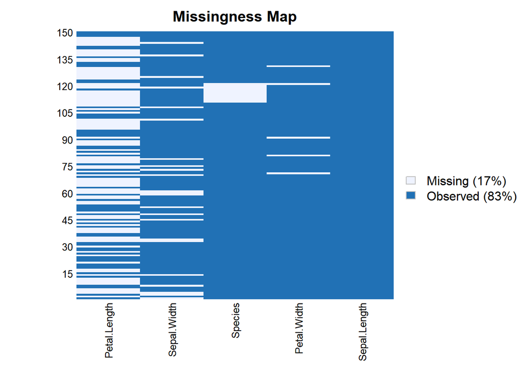

Mapa de perdidos

```r
library(Amelia)
missmap(datos.na)
```

Ahora que tenemos identificados los valores perdidos podemos hacer algo al respecto. Imaginemos que queremos descartar `Petal.Length` (la tercera columna). Observa que la función ordena las variables de mayor a menor en función de sus valores perdidos.

```r
datos.na <- datos.na[,-3]
datos.na <- datos.na[,c(1:4)]
datos.na <- datos.na[,c("Species","Petal.Width","Sepal.Length", "Sepal.Width")]
# equivalentes
```

Otra forma de tratar con valores perdidos, es ignorar las observaciones que contengan alguno. Podemos emplear la función `completecases`. Esta función devuelve un vector lógico con las filas que contienen todos los casos.

```r
complete.cases(datos.na)
```

```
##   [1]  TRUE  TRUE  TRUE  TRUE  TRUE  TRUE FALSE  TRUE  TRUE  TRUE  TRUE  TRUE
##  [13]  TRUE FALSE  TRUE  TRUE  TRUE  TRUE  TRUE FALSE  TRUE  TRUE  TRUE  TRUE
##  [25]  TRUE FALSE  TRUE  TRUE  TRUE FALSE FALSE FALSE FALSE FALSE FALSE FALSE
##  [37] FALSE FALSE FALSE FALSE  TRUE  TRUE FALSE  TRUE  TRUE  TRUE  TRUE  TRUE
##  [49]  TRUE FALSE  TRUE  TRUE  TRUE  TRUE  TRUE  TRUE  TRUE  TRUE  TRUE FALSE
##  [61]  TRUE  TRUE  TRUE  TRUE  TRUE  TRUE  TRUE  TRUE  TRUE FALSE  TRUE FALSE
##  [73]  TRUE  TRUE  TRUE FALSE  TRUE FALSE  TRUE FALSE FALSE  TRUE  TRUE  TRUE
##  [85]  TRUE  TRUE  TRUE  TRUE  TRUE FALSE FALSE FALSE  TRUE  TRUE  TRUE  TRUE
##  [97]  TRUE  TRUE FALSE  TRUE  TRUE  TRUE FALSE  TRUE  TRUE FALSE  TRUE  TRUE
## [109]  TRUE  TRUE  TRUE  TRUE  TRUE  TRUE  TRUE  TRUE FALSE FALSE  TRUE  TRUE
## [121]  TRUE  TRUE  TRUE  TRUE  TRUE  TRUE  TRUE  TRUE  TRUE  TRUE  TRUE  TRUE
## [133]  TRUE  TRUE  TRUE  TRUE FALSE  TRUE  TRUE  TRUE  TRUE  TRUE FALSE  TRUE
## [145]  TRUE  TRUE FALSE FALSE  TRUE FALSE
```

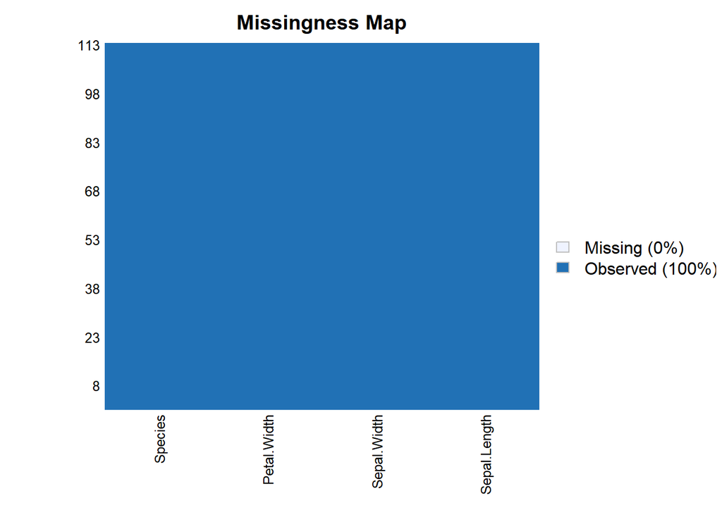

```r
# ahora se la pasamos a las filas

datos.na2 <- datos.na[complete.cases(datos.na),]
missmap(datos.na2)
```

Como vemos la matriz esta “limpia”. Lamentablemente en el proceso perdemos información. Otra forma de lidiar con los valores perdidos es ignorarlos.

Imaginemos que queremos sacar la media de “Petal.Width”

```r
mean(datos.na$Petal.Width)
```

```
## [1] NA
```

Afortunamende muchas funciónes incroporan un argumento para lidiar con los valores perdidos. En este caso el argumento `na.rm`(NA remove) nos permite omitir estos casos para el cálculo

```r
mean(datos.na$Petal.Width, na.rm = T)
```

```
## [1] 1.213103
```

## Frecuencias

Para obtener las frecuencias de una variable en R empleamos al función `table()`. Esta nos devuelve un vector que contiene las frecuencias absolutas.

```r
table(datos$Species)
```

```
##
## se ve vi
## 50 50 50
```

Podemos obtener una tabla de contingencia añadiendo el otro vector a la función.

```r
table(datos$Species,datos$cPet4)
```

```
##
##      Uno Dos Tres
##   se  37  13    0
##   ve   0  49    1
##   vi   0   9   41
```

El argumento `useNA` nos permite excluir los valores perdidos en caso de haberlos.

## Distribuciones

A continuación damos algunos ejemplos de cómo se trabajan las distribuciones en R.

**Binomial**

Sea $X \in B(n,p)$ una v.a. con función de probabilidad:
$$P(X = x) = \binom{n}{x}p^xq^{n-x} \;\;\;\; \text{si}\;\;\;x=0,1,2,...,n$$
Con,
$$E(X) = np, \;\;\;\;\; Var(X) = npq$$

En R tenemos cuatro sentencias:

- `pbinom()` CDF / PMF
- `dbinom()` PDF
- `qbinom()` Cuantil.
- `rbinom()` Números pseudo-aleatorios que seguirán mi distribución.

Esta misma lógica impera para las demás distribuciones notables. Por ejemplo, supongamos que $X \in B(10, 0.1)$ y que nos interesa $P(X=1)$ entonces,

```r
dbinom(1, 10, 0.1)
```

```
## [1] 0.3874205
```

*Los decimales en R se separan con puntos `.` no con comas `,`. Si estás acostumbrado a la notación española es común que puedas equivocarte. Tip: En vez de decir “cero coma uno” intenta decir “cero punto uno”, de esta manera evitarás equivocarte cuando estés programando.*

De manera análoga podemos calcular la función de densidad.

Supongamo que nos interesa evaluar en los puntos 0,1,…,5 y además queremos representarlos gráficamente. Entonces,

```r
ex <- 0:5
f <- dbinom(ex, 10, 0.1) #En vez de pasarle sólo un número al primer argumento, le pasamos una sentencia.
```

Hasta aquí tenemos dos objetos: Uno que contiene una secuencia de enteros y otro con nuestra función de probabilidad.

- `cbind()` *Toma vectores, matrices o data frames y los combina en columnas.*

Vamos a hacer un data frame con los dos y lo representaremos.

```r
df <- cbind(ex, f)
df
```

```
##      ex           f
## [1,]  0 0.348678440
## [2,]  1 0.387420489
## [3,]  2 0.193710244
## [4,]  3 0.057395628
## [5,]  4 0.011160261
## [6,]  5 0.001488035
```

- `plot()` Función genérica de graficado base.

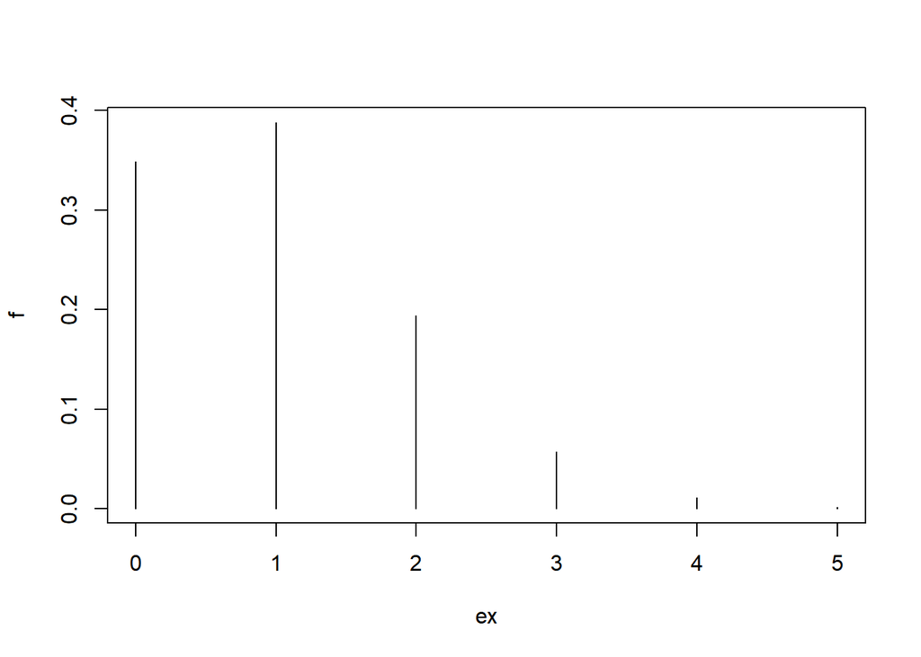

```r
plot(df, type = "h") # El argumento type = "h" nos da líneas verticales.
```

```r
mean(dbinom(ex, 10, 0.1))
```

```
## [1] 0.1666422
```

```r
var(dbinom(ex, 10, 0.1))
```

```
## [1] 0.02919965
```

Para las demás distribuciones los nombres de las funciones en R siguen la misma lógica.

- `help(distributions)` Muestra la documentación de las distribuciones.
- `dbinom(k, n, p)` PMF $P(X = k)$ $X \sim$ Bin(n,p)
- `pbinom(x, n, p)` CDF $P(X \leq x)$ for X $\sim$ Bin(n,p)
- `qbinom(a, n, p)` Cuantil min{x : $P(X \leq x)$ a} for X $\sim$ Bin(n,p)
- `rbinom(r, n, p)` Vector pseudo-aleatorio i.i.d. Bin(n,p) v.a.s.
- `dgeom(k, p)` PMF P(X = k) for X $\sim$ Geom(p)
- `dhyper(k, w, b, n)` PMF P(X = k) de X $\sim$ HGeom(w,b,n)
- `dnbinom (k, r, p)` PMF P(X = k) de X $\sim$ NBin(r,p)
- `dpois(k, r)` PMF P(X = k) de X $\sim$ Pois(r)
- `dbeta(x, a, b)` PDF $f(x)$ de X $\sim$ Beta(a,b)
- `dcauchy(x)` PDF $f(x)$ de X $\sim$ Cauchy
- `dchisq(x, n)` PDF $f(x)$ de X $\sim X_n^2$
- `dexp(x, b)` PDF $f(x)$ de X $\sim$ Expo(b)
- `dgamma(x, a, r)` PDF $f(x)$ de X $\sim$ Gamma(a,r)
- `dlnorm(x, m, s)` PDF $f(x)$ de X $\sim LN(m,s^2)$
- `dnorm(x, m, s)` PDF $f(x)$ de X $N(m,s^2) $
- `dt(x, n)` PDF $f(x)$ de X $\sim$tn
- `dunif(x, a, b)` PDF $f(x)$ de X $\sim$ Unif(a,b)

## Plot base

Tomaremos la base de datos `airquality` para realizar los principales gráficos exploratorios. Los gráficos del R base son sobrios y suelen utilizarse no para presentar resultados -aunque también- sino para explorar nuestro fichero de datos. Para realizar gráficos de alta calidad utilizaremos la librería `ggplot2`

- **Gráfico de dispersión**
- `plot()` *Función polimórfica que se adapta a nuestros datos*

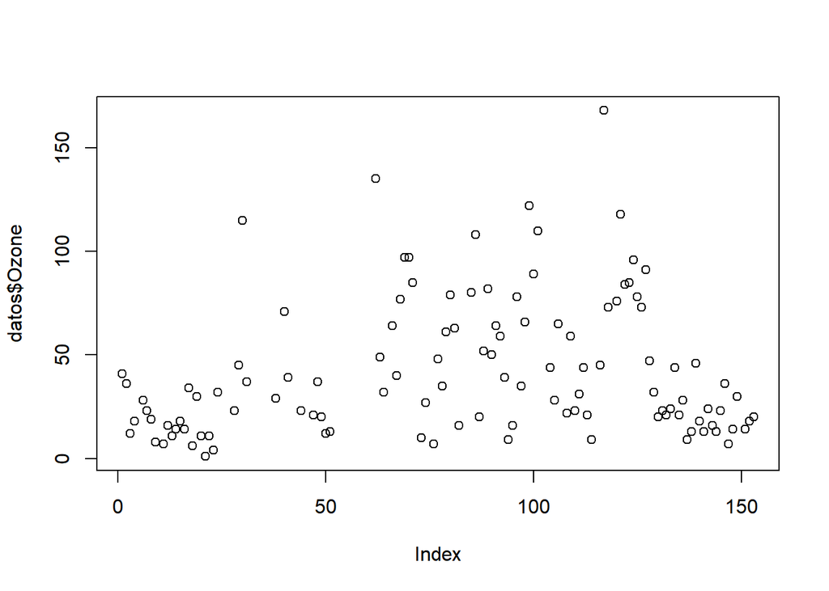

```r
datos <- airquality
plot(datos$Ozone)
```

En el eje x está el índice y en el eje y el valor que toma cada observación. La función acepta una cantidad enorme de argumentos, de tal manera que podemos llegar a tener el control de todos los elementos que que observamos en el gráfico. A continuación vemos los más comunes.

- `main =` Título.
- `xlab =` = Leyenda del eje x.
- `ylab =` Leyenda del eje y.
- `sub =` Subtítulo.
- `xlim =` Límite de las x.
- `ylim =` Límite de las y.
- `pch =` Tipo de punto.

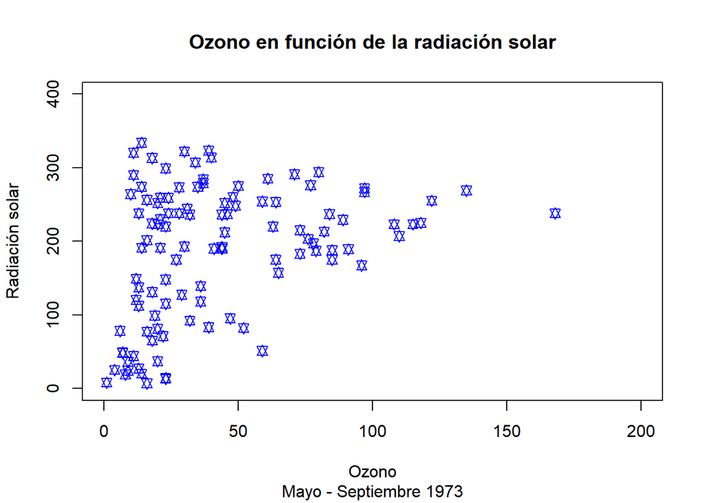

```r
 plot(datos$Ozone, datos$Solar.R, main = "Ozono en función de la radiación solar",
     xlab = "Ozono", ylab = "Radiación solar",
     sub = "Mayo - Septiembre 1973",
     xlim = c(0, 200), ylim = c(0, 400),
     pch = 11, col = "blue")
```

Rbase va pintando los datos por capas. Así, sobre el gráfico que ya tenemos podemos ir incorporando otro tipo de datos:

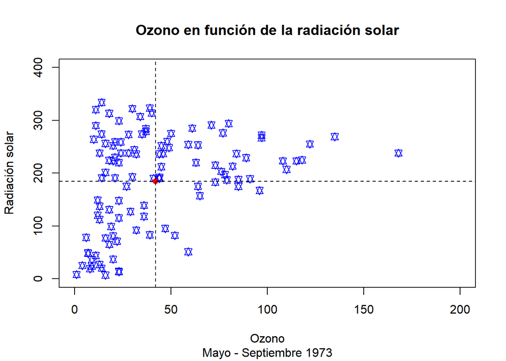

```r
datos <- na.omit(datos) #quitamos los valores perdidos
 plot(datos$Ozone, datos$Solar.R, main = "Ozono en función de la radiación solar",
     xlab = "Ozono", ylab = "Radiación solar",
     sub = "Mayo - Septiembre 1973",
     xlim = c(0, 200), ylim = c(0, 400),
     pch = 11, col = "blue")

#Añadimos el centro de los datos
cordx <- mean(datos$Ozone)
cordy <- mean(datos$Solar.R)
points(x = cordx, y = cordy, pch = 19, col = "red")
abline(v = cordx, lty = 2) #lty es el tipo de línea. v = "vertical"
abline(h = cordy, lty = 2) #lty es el tipo de línea. h = "horizontal"
```

Otros parámetros que podemos controlar se muestran en la siguiente imagen.

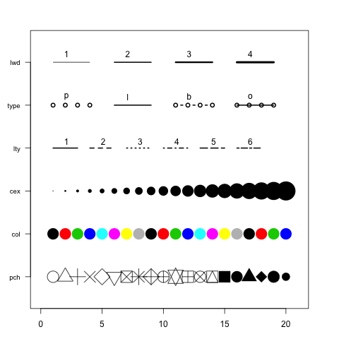

Otros parámetros

O incluso pintar los puntos de otras variables.

- `scale()` *Estandarización de los datos*

Dado que tenemos diferentes escalas de medida, vamos a estandarizar (univariante) los datos. Esto lo podemos hacer con la función `scale()` para tener normales de media 0 y $\sigma = 1$ $X \approx N(0,1)$

En vez de estandarizar una por una lo que hacemos es un loop

```r
#seleccionamos todas menos `Day`
datos <- datos %>% select(-Day)

#loop con purrr
library(purrr)
datos.est <- modify_if(datos, is.numeric, scale)
```

`modify_if` es un loop condicional dentro de la librería `purrr` del universo tidyverse. Lo que estamos diciendo en la sentencia es: *“evalúa cada columna (variable) de mi matriz `datos`, si ésta es numérica entonces aplícale la función `scale`, si no es numérica no hagas nada”*. Podemos comprobar que ahora el vector de medías es $\bar{x} = (0,0,0,0)'$ y las varianzas = 1

```r
colMeans(datos.est[1:4])
```

```
##         Ozone       Solar.R          Wind          Temp
## -1.456543e-17 -1.512491e-16 -2.127927e-16 -2.741801e-16
```

```r
map(datos.est[,1:4], mean) #equivalente
```

```
## $Ozone
## [1] -1.445896e-17
##
## $Solar.R
## [1] -1.511847e-16
##
## $Wind
## [1] -2.128589e-16
##
## $Temp
## [1] -2.742465e-16
```

```r
sapply(datos.est[,1:4], mean) #equivalente
```

```
##         Ozone       Solar.R          Wind          Temp
## -1.445896e-17 -1.511847e-16 -2.128589e-16 -2.742465e-16
```

```r
#varianzas
sapply(datos.est[,1:4], var) #varianzas
```

```
##   Ozone Solar.R    Wind    Temp
##       1       1       1       1
```

Ahora que tenemos estandarizados nuestros datos continuemos con el plan. Queremos representar puntos de otras variables en nuestro gráfico de dispersión.

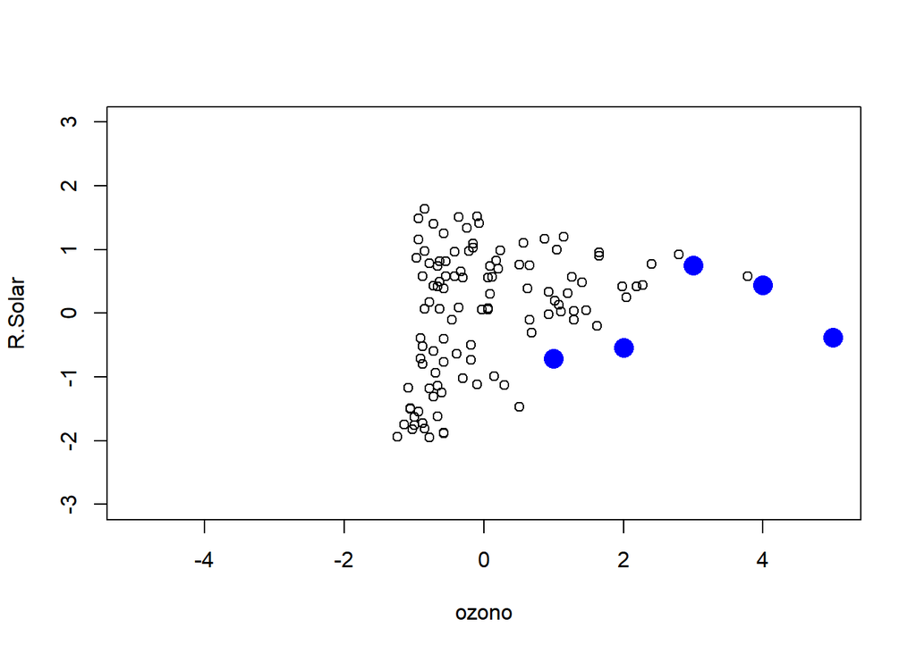

```r
plot(datos.est$Ozone, datos.est$Solar.R, xlab = "ozono", ylab = "R.Solar",
     xlim = c(-5, 5), ylim = c(-3,3))
points(datos.est$Wind, col = "blue", pch = 16, cex = 2)
```

- **Histograma**

El histograma, que es un estimador (malo) de la densidad podemos representarlo de la siguiente manera:

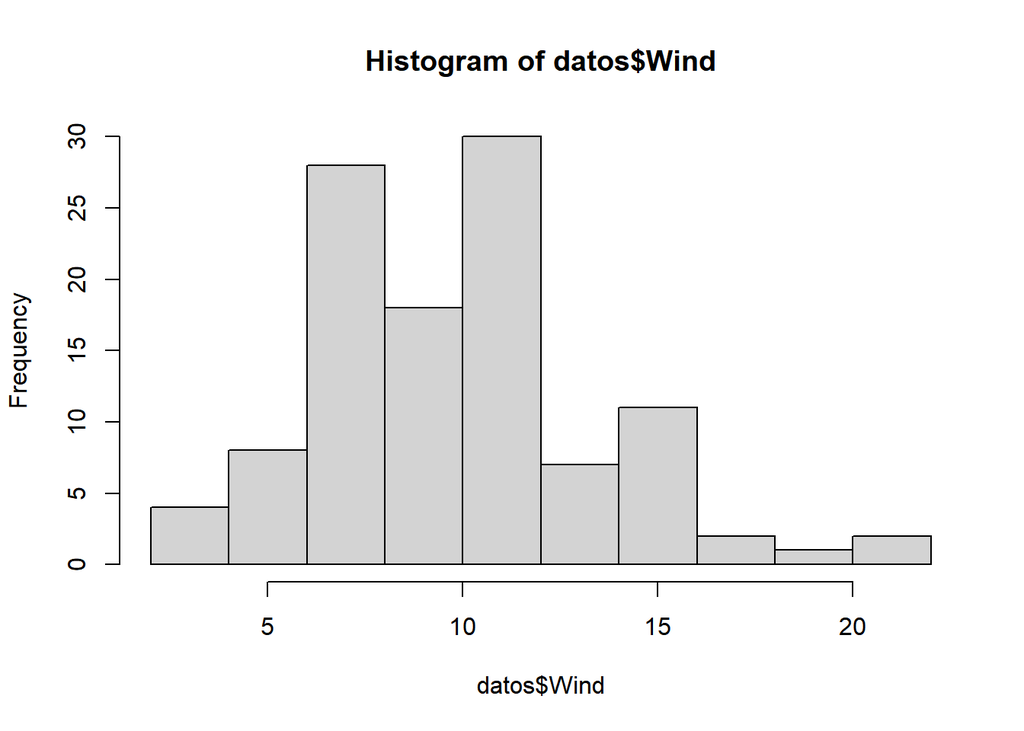

```r
hist(datos$Wind)
```

Elegir el número de cortes es una cuestión importante. Se sugiere utilizar la regla de Sturges:

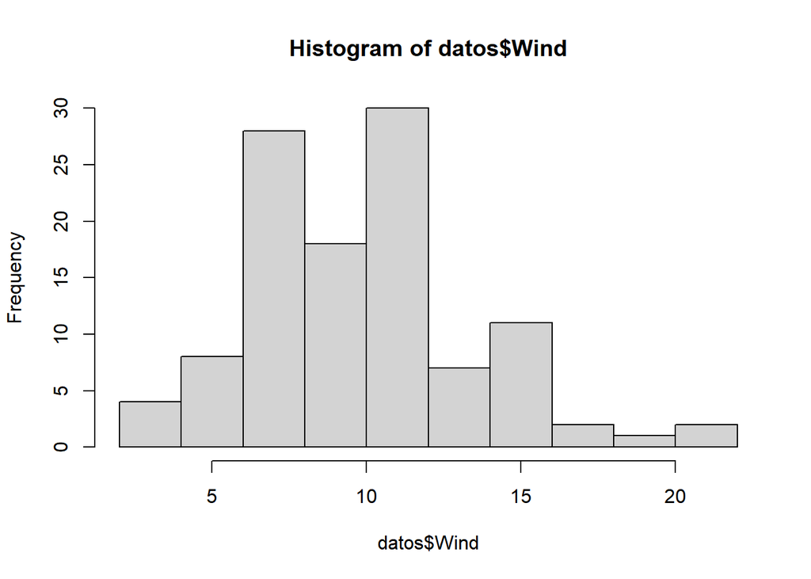

```r
hist(datos$Wind, breaks = "Sturges")
```

Podemos incluso pedirle que nos muestre la probabilidad:

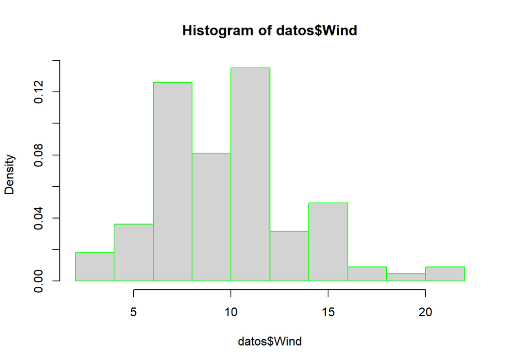

```r
hist(datos$Wind, probability = T, breaks = "Sturges",
     border = "green")
```

- **Boxplot**

Transformamos los datos de los meses para que la variable sea tipo factor

```r
datos$Month <- factor(datos$Month, labels = c("mayo", "junio", "julio", "agosto", "septiembre"))
levels(datos$Month)
```

```
## [1] "mayo"       "junio"      "julio"      "agosto"     "septiembre"
```

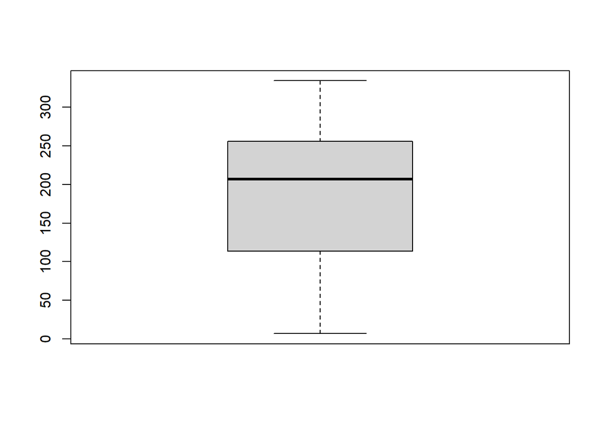

```r
boxplot(datos$Solar.R)
```

Para ver una variable en función a otra tipo factor en el boxplot, utilizaremos el símbolo `~` que podemos leer como “en función de…”

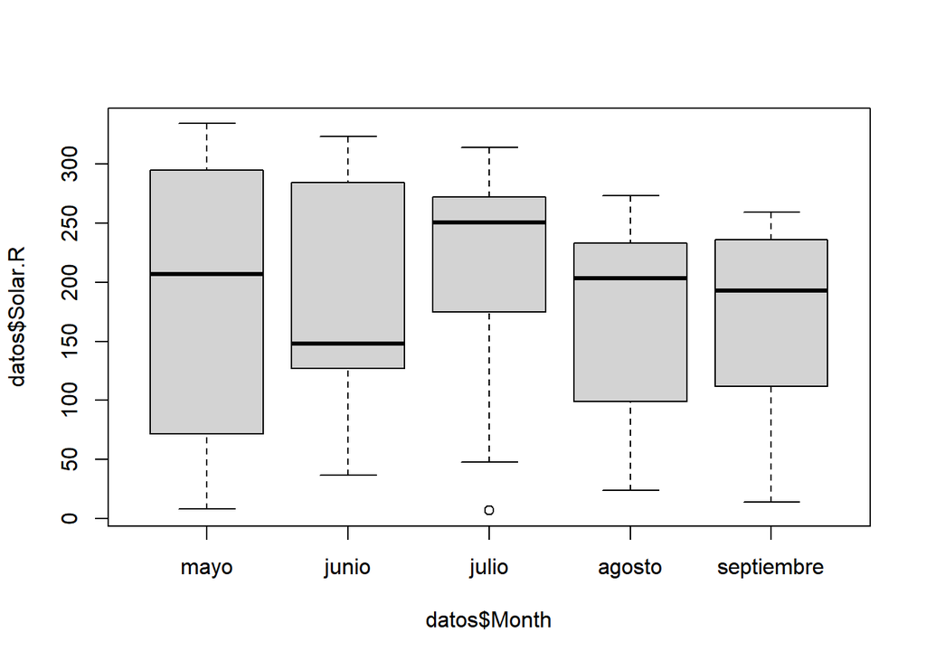

```r
boxplot(datos$Solar.R ~ datos$Month)
```

- **Correlaciones**

Si a la función `plot()` le pasamos una matriz, por defecto nos crea un gráfico de correlaciones para aquellas variables numéricas.

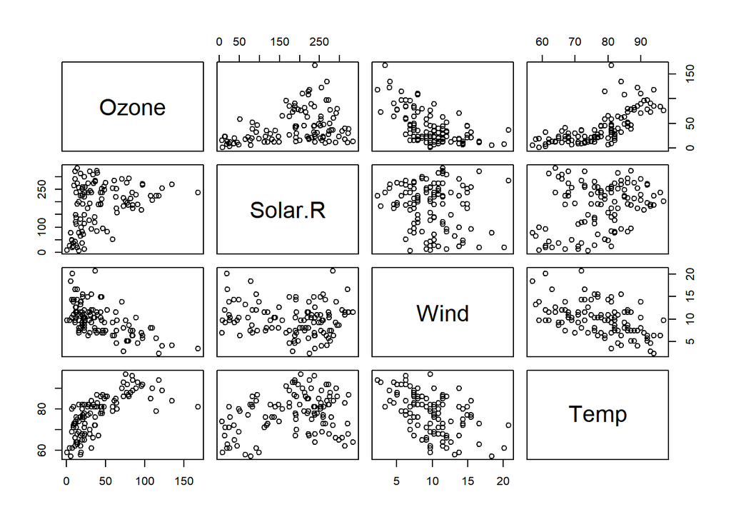

```r
plot(datos[,1:4])
```

Recordamos que la matriz de correlaciones podemos obtenerla con la función `cor()`

```r
cor(datos[,1:4])
```

```
##              Ozone    Solar.R       Wind       Temp
## Ozone    1.0000000  0.3483417 -0.6124966  0.6985414
## Solar.R  0.3483417  1.0000000 -0.1271835  0.2940876
## Wind    -0.6124966 -0.1271835  1.0000000 -0.4971897
## Temp     0.6985414  0.2940876 -0.4971897  1.0000000
```

La matriz de covarianzas la obtenemos con la función `cov()`. Por defecto, R utiliza la insesgada.

```r
cov(datos[,1:4]) #Pongo 1:4 porque le indico las variables que son numéricas
```

```
##              Ozone   Solar.R      Wind      Temp
## Ozone   1107.29009 1056.5835 -72.51124 221.52072
## Solar.R 1056.58346 8308.7422 -41.24480 255.46765
## Wind     -72.51124  -41.2448  12.65732 -16.85717
## Temp     221.52072  255.4676 -16.85717  90.82031
```

Donde las diagonales es el vector de varianzas. Notamos que es una matriz simétrica.

```r
sapply(datos[,1:4], var)
```

```
##      Ozone    Solar.R       Wind       Temp
## 1107.29009 8308.74218   12.65732   90.82031
```

```r
diag(cov(datos[,1:4])) #Equivalente. Diag me devuelve los valores de la diagonal
```

```
##      Ozone    Solar.R       Wind       Temp
## 1107.29009 8308.74218   12.65732   90.82031
```